# **Simulating and Pricing Barrier Options**

Comparing Monte Carlo and Black-Scholes Valuation of Down and Out Puts

Gary He

# 1 Brownian motion with bounds

Brownian motion is often used to model stock prices as a stochastic process. Often, in quantitative finance and scientific fields such as Biology and Physics, whilst Brownian motion is a useful model in and of itself for the random movement of particles, it is useful to be able to implement boundaries for a particular path. For example, the narrow escape problem in Biology describes a situation in which a Brownian particle is confined to a bounded domain, such as a cell.

In derivatives markets, barriers and the bounding of a Brownian motion are important for pricing **barrier options**. These, and variations of them, serve important roles in option and structured product markets. For example, barrier options often allow access to a certain payoff, at a cheaper price due to the possibility of the option being ‘knocked out’ and becoming worthless should the stock price breach a pre-defined ‘barrier’.

## 1.1 Simulating a bounded 1-dimensional Brownian motion

To simulate and price barrier options, we first look at what a bounded Brownian motion looks like. We do this by simply plotting a standard Brownian against an upper and lower boundary. This is easy to accomplish in R, due to the ease of generating random, iid normal variates:

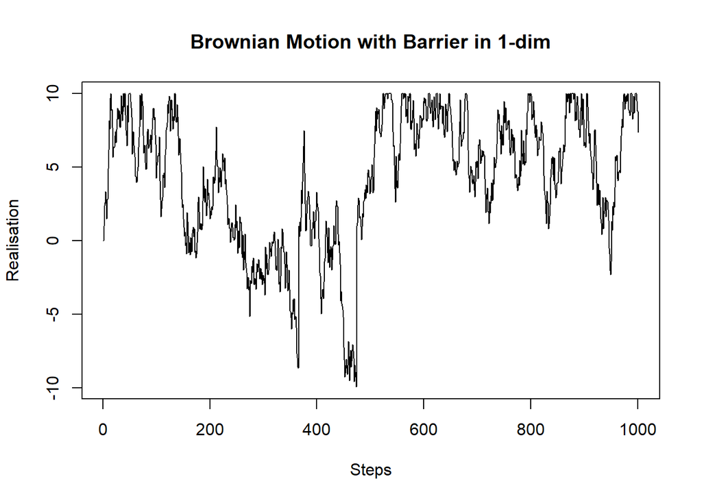

## 1.2 Simulating a bounded stock price with geometric Brownian motion

We now look to apply this to a standard geometric Brownian motion on which a stock price can be modelled, with drift and diffusion. This takes the form:

$$dS_t = \mu S_t dt + \sigma S_t dW_t$$

We create a simple function to demonstrate how the stock price looks if confined to an upper and lower bound. We define the following parameters:

```r
#pc = 0 #put/call indicator, put is 0 and call is 1
#S = 100 #initial stock price
#T = 1 #total time period observed, frequency is in years
#N = 1000 #total steps
#h = 1/1000 #step size, defined as T/N
#mu = 0 #drift or expected return
#sigma = 0.4 #diffusion or volatility
#ub = 120 #upper bound
#lb = 80 #lower bound
```

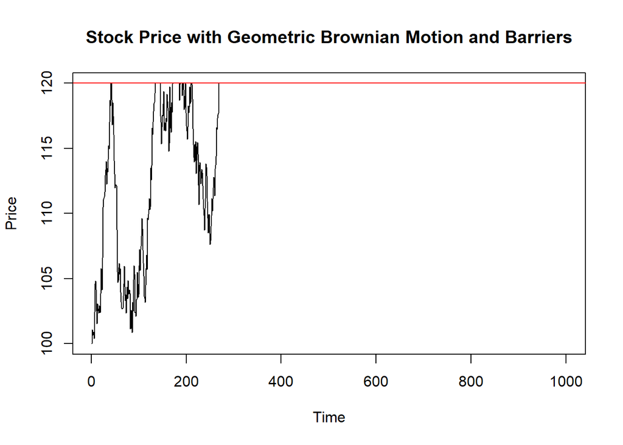

```r
gbmbarrierplot<-function(S,T,N, mu,sigma,ub,lb)
{
  h <- 1/N
  x <<- (mu-sigma^2/2)*h+sigma*sqrt(h)*rnorm(T*N, 0, 1)
  x <<- S*exp(cumsum(x))
  x<<- c(S,x)
  for(i in 2:length(x)) {
    if(x[i]>=ub) {
      x[i] = ub;
    } else if(x[i]<=lb) {
      x[i] = lb
    } else{x[i] = x[i]
    }}
  plot(x,type="l",main="Stock Price with Geometric Brownian Motion and Barriers",xlab="Time",ylab="Price")
  abline(h=c(ub,lb),col="red")
}

gbmbarrierplot(100,1,1000,0,0.4,120,80)
```

## 1.3 Obtaining a bounded stock price

For the purposes of pricing, we want the asset to become worthless, or revert to a value of 0, in the event that a boundary is crossed. We achieve this using the following function and retrieve the terminal value:

```r
gbmbarrierprice<-function(S,T,N, mu,sigma,ub,lb)
{
  h <- 1/N
  x <<- (mu-sigma^2/2)*h+sigma*sqrt(h)*rnorm(T*N, 0, 1)
  x <<- S*exp(cumsum(x))
  x<<- c(S,x)
  upout = FALSE
  downout = FALSE
  for(i in 2:length(x)) {
    if(x[i]>=ub && upout == FALSE && downout == FALSE) {
      x[i] = 0;
      upout = TRUE
    } else if(x[i]<=lb && upout == FALSE && downout == FALSE) {
      x[i] = 0
      downout = TRUE
    } else if(upout||downout) {x[i] = 0
    } else{x[i] = x[i]
    }}
  return(x[length(x)])
}

gbmbarrierprice(100,1,1000,0,0.4,120,80)
```

```
## [1] 0
```

# 2 Pricing a down-and-out barrier option

## 2.1 Using Monte Carlo valuation

Now we will see if we can generate an approximation of a down-and-out barrier option, using Monte Carlo simulations and the bounded Brownian motion:

```r
mc_downout = function(pc,nsims,S,T,N,r,sigma,L,K) {
c=c()
for(i in 1:nsims) {
  c[i] = gbmbarrierprice(S,T,N,r,sigma,Inf,L)
}
d = matrix(t(c)[t(c) != 0])

if(pc == 0) {
  for(i in 1:length(d)) {
  d[i] = max(K-d[i],0)
}
} else if(pc == 1) {
  for(i in 1:length(d)) {
    d[i] = max(d[i]-K,0)
  }
}

return(sum(d)/nsims)
}

mc_downout(0,10000,100,1,1000,0,0.4,90,100)
```

```
## [1] 0.02554642
```

## 2.2 Using Black-Scholes valuation

To see if this is a reasonable approximation of the down-and-out put price, we compare against the Black-Scholes model. It can be shown that a down-and-out put is given by:

$$P(S_t,\varphi) = P(S_t, \varphi_L) - (\frac{L}{S_t})^{\frac{2r}{\sigma^2}-1} P (\frac{L^2}{S_t},\varphi_L)$$

Where phi represents the option payoff, and the subscript L represents the payoff of a vanilla option bounded by L (but not knocked out if touching the boundary).

This can be expressed as:

$$P(S,K,L) = P_BS (S,L) - P_BS (S,L) - \frac{(S-L)(L+1)}{L} CONP_BS (S,L) + \frac{K}{L} [C_BS(S,L) - C_BS (S, \frac{L^2}{K})] + (K-L)$$

Where CONP represents a cash or nothing put, and BS represents a vanilla option as priced by Black-Scholes.

Thus we can put together a function for the Black-Scholes priced down-and-out-put without dividends:

```r
downoutput<-function(S, K, v, r, T, L)
  # Computes the Black-Scholes price of a down and out barrier option, no dividends
  #S   Stock price at 0
  #K   strike
  #v   volatility
  #r   riskless rate
  #T   time to maturity
  #L   barrier

{
  r1 = r - (v^2) / 2;
  r2 = r + (v^2) / 2;

  A1 = exp(-r*T) * K * pnorm((log(K/S) - r1*T) / (v*sqrt(T)));
  A2 = S * pnorm((log(K/S) - r2*T) / (v*sqrt(T)));
  A3 = exp(-r*T) * K * pnorm((log(L/S) - r1*T) / (v*sqrt(T)));
  A4 = S * pnorm((log(L/S) - r2*T) / (v*sqrt(T)));
  A5 = exp(-r*T) * K * pnorm((log(K*S/(L^2)) - r1*T) / (v*sqrt(T)));
  A6 = (L^2) * pnorm((log(K*S/(L^2)) - r2*T) / (v*sqrt(T))) / S;
  A7 = exp(-r*T) * K * pnorm((log(S/L) - r1*T) / (v*sqrt(T)));
  A8 = (L^2) * pnorm((log(S/L) - r2*T) / (v*sqrt(T))) / S;

  B1 = (L/S)^(2*r / (v^2) - 1);

  y = A1 - A2 - A3 + A4 - B1 * (A5 - A6 - A7 + A8);
  return(y)
}

downoutput(100,100,0.4,0,1,90)
```

```
## [1] 0.02400089
```

## 2.3 Assessing the accuracy of Monte Carlo in approximating Black-Scholes

We can see that whilst our Monte Carlo valuation is incorrect, it is relatively close to the Black-Scholes approximation with adequate simulations conducted.

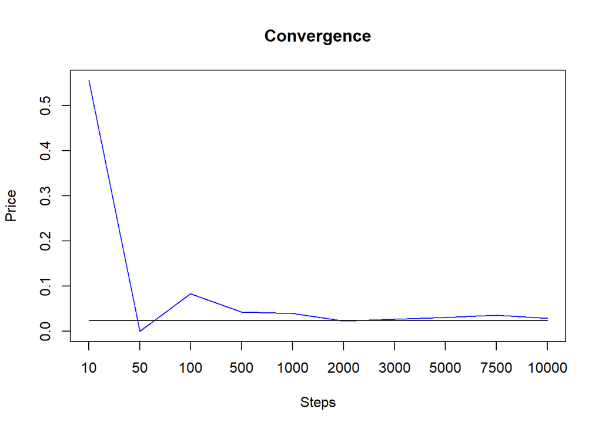

```r
steps = c(10,50,100,500,1000,2000,3000,5000,7500,10000)
n = length(steps)

MC_Prices = rep(0,n);
for(i in 1:n) {
  MC_Prices[i] = mc_downout(0,steps[i],100,1,1000,0,0.4,90,100)
}

BS_Prices = downoutput(100,100,0.4,0,1,90) * rep(1,n)

plot(MC_Prices,main='Convergence',xaxt="n",type="l",col="blue",xlab="Steps",ylab="Price")
axis(1,at=1:10,labels=steps)
lines(BS_Prices,col="black")
```